# Automation for Rbanism

2022-08-24

## Follow along!

[tinyurl.com/urbanism-script](https://github.com/Rbanism/repro-r-workshop-livecode/blob/main/R/my-first-R-script.R)

## Make an R project

Start from a folder, in which an R project is generated. This will help you work within the project, and create relative paths.

In order to work from the root, we will also make use of a package called `here`.

We will install it first:

```r
install.packages("here")
```

## Load packages

```r
library(here)
library(tidyverse)
```

## Load data

First, we have to describe where the data is.

We can do this in two ways: a relative and an absolute way.

```r
data_relative <- "../data/urban_population.csv"
print(data_relative)
```

```
## [1] "../data/urban_population.csv"
```

```r
data_absolute <- here("data", "urban_population.csv")
print(data_absolute)
```

```
## [1] "/Users/bvreede/Projects/fellowship/repro-r-workshop/data/urban_population.csv"
```

We always prefer the relative path, because that means that the code is transferrable. But, here we are using a special tool, which may create an absolute path, but the code *itself* does not contain the absolute path’s information. So in this case, the absolute path is the one we will use!

Then we are going to load the data.

We will take a look at the Import Dataset option to get an idea about the function to use:

Environment pane > Import Dataset > From Text (readr).

This gives us the code we can use:

```r
df <- read_csv(data_absolute)
```

Take a look at the different columns and ascertain at this point that they are the right type!

## Small transformations in the data

We can do many things at this point.

For example, we can make a selection

```r
df_europe <- filter(df, continent == "EUROPE")
```

We can make a new column:

```r
df_newccol <- mutate(df, population_in_1000 = population_in_cities/1000)
```

We can even make categories:

```r
df_categorized <- mutate(df,
                         data_type = case_when(
                           year < 2020 ~ "data",
                           year >= 2020 ~ "prediction"
                           )
                         )
```

We can summarize the data, but for this, let’s look at a neat feature: the pipe

```r
df_filtered1 <- df |> filter(year < 2020)

df_filtered2 <- filter(df, year < 2020)
```

Let’s use this trick:

```r
df_grouped <- df |>
  group_by(city_size) |>
  summarise(population=sum(population_in_cities))
```

We can add things, like a separation per continent:

```r
df_grouped <- df |>
  group_by(continent, city_size) |>
  summarise(population=sum(population_in_cities))
```

Or even an additional calculation:

```r
df_grouped <- df |>
  group_by(continent, city_size) |>
  summarise(population=sum(population_in_cities),
            average_percentage=mean(percentage_of_population)
            )
```

And with the pipe structure, we can add filters to this workflow:

```r
df_grouped <- df |>
  filter(year==2020) |>
  group_by(continent, city_size) |>
  summarise(population=sum(population_in_cities),
            average_percentage=mean(percentage_of_population)
            )
```

## Visualize the data

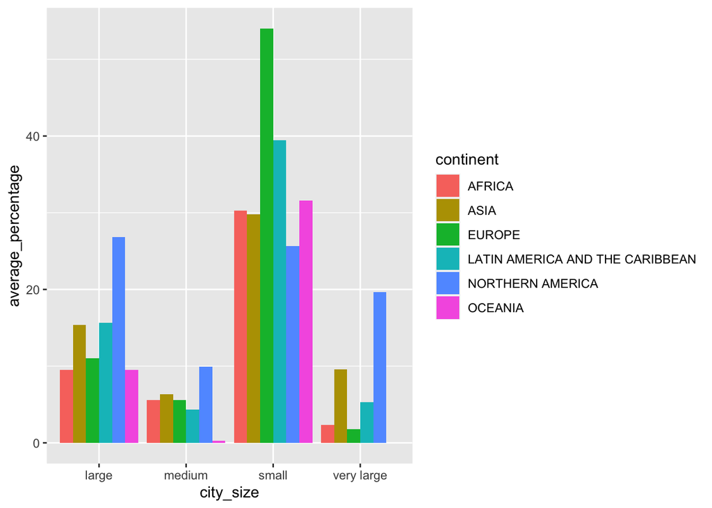

```r
df_grouped |>
  ggplot(aes(x = city_size,
             y = average_percentage,
             fill = continent)) +
  geom_bar(position = position_dodge(),
           stat="identity")
```

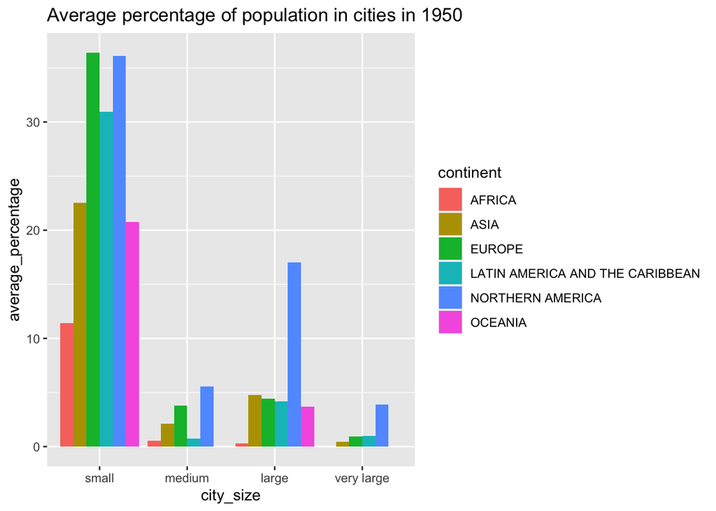

```r
df |>
  filter(year==1950) |>
  group_by(continent, city_size) |>
  summarise(average_percentage=mean(percentage_of_population)) |>
  mutate(city_size=fct_relevel(city_size,c("small", "medium", "large", "very large"))) |>
  ggplot(aes(x = city_size,
             y = average_percentage,
             fill = continent)) +
  geom_bar(position = position_dodge(),
           stat="identity") +
  labs(title = "Average percentage of population in cities in 1950")
```

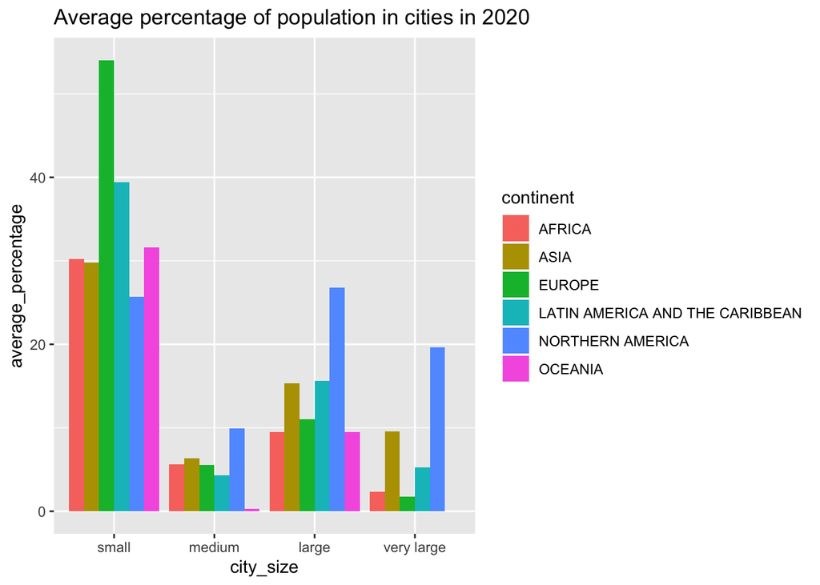

```r
df |>
  filter(year==2020) |>
  group_by(continent, city_size) |>
  summarise(average_percentage=mean(percentage_of_population)) |>
  mutate(city_size=fct_relevel(city_size,c("small", "medium", "large", "very large"))) |>
  ggplot(aes(x = city_size,
             y = average_percentage,
             fill = continent)) +
  geom_bar(position = position_dodge(),
           stat="identity") +
  labs(title = "Average percentage of population in cities in 2020")
```

```r
library(viridis)
```

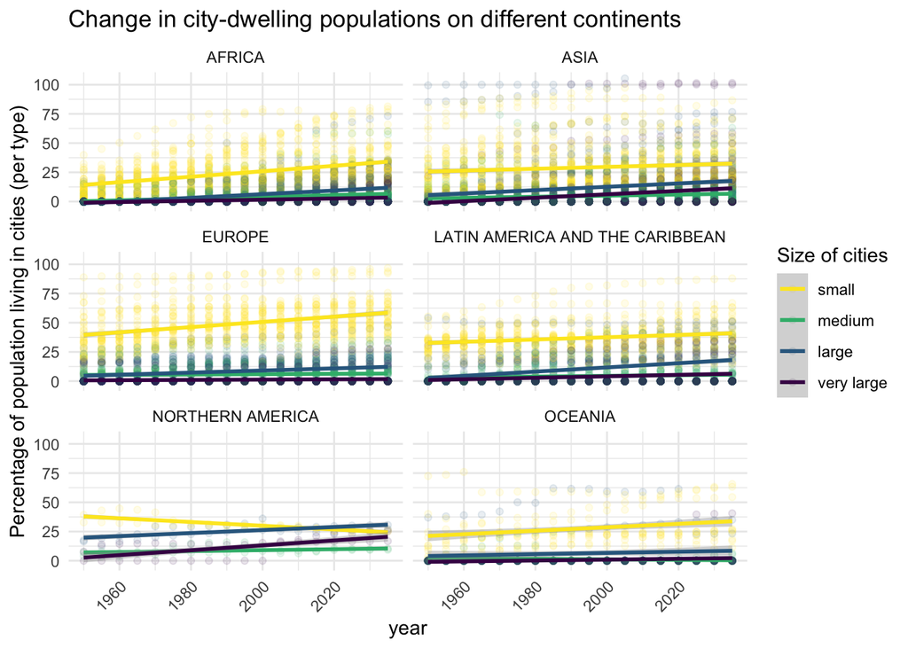

```r
df |>
  mutate(city_size=fct_relevel(city_size,c("small", "medium", "large", "very large"))) |>
  ggplot(aes(x = year,
             y = percentage_of_population,
             color = city_size)) +
  scale_color_viridis(discrete=T, direction=-1) +
  geom_point(alpha=0.1) +
  geom_smooth(method = "glm") +
  facet_wrap("continent", ncol=2) +
  theme_minimal() +
  theme(axis.text.x = element_text(angle = 45, vjust = 1, hjust=1)) +
  labs(
    title = "Change in city-dwelling populations on different continents",
    y = "Percentage of population living in cities (per type)",
    color = "Size of cities"
  )
```

Finally, let’s save these results:

```r
ggsave("../results/city-dwellers-over-time.png")
# or

ggsave(here("results", "city-dwellers-with-here.png"))
```